# MAB Simulations

Sandeep Gangarapu

# Simulation set up

Every time we pull an arm (make an allocation), we sample from the normal distribution of given by the mean and variance of that arm.

```r
true_means = c(0.25, 1.82, 1.48, 2.25, 2)
true_vars = c(2.84,  1.97, 2.62, 1, 2.06)

grp = c(0:(length(true_means)-1))
true_df <- data.frame(grp, true_means, true_vars)
true_df <- true_df %>% mutate(grp=factor(grp))
```

Time Horizon is the number of allocations we have available synonymous to number of experimental units in an experiment. In this simulation, we set time horizon to 2000 units.

We run this simulation for 20 different times using various seeds.

# Group allocation graphs

We first look at the allocations for widely used algorithms.

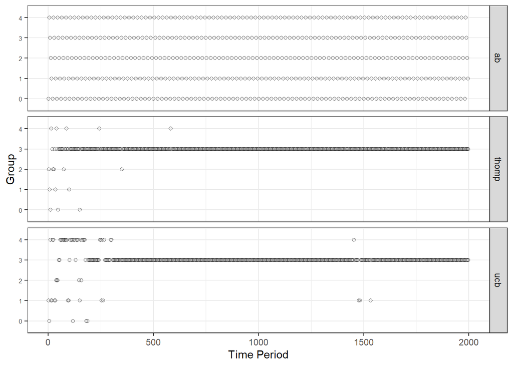

## Group allocations for Inference based allocation algorithms.

For inference based allocation, we deviate from the main allocation algorithm with the probability of $\epsilon_n$ defined by

$\eta = \frac{\sum{\frac{\sigma^2}{n}}}{\xi K}$ $\epsilon_n = \frac{\eta}{1+\eta}$

$\xi$ and $K$ are user defined parameters that we will discuss later.

The main idea is that by deviating from main algorithm and making inference based allocations, we learn more about an arm. Learning here implies reducing standard error of an arm. This ofcourse comes at the cost of Utility.

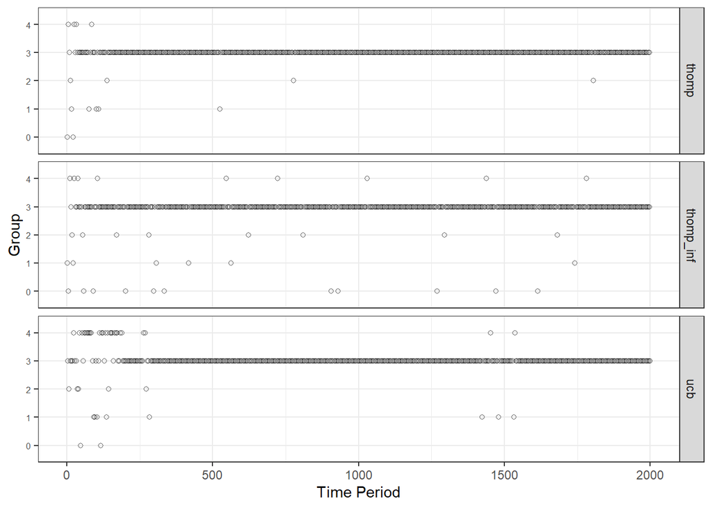

"_inf" suffix suggests that the algorithms makes inference based allocation with some probability. In these algorithms, the allocations are not as concentrated around few arms as those of the main algorithms (UCB, Thompson Sampling).

# Regret Analysis

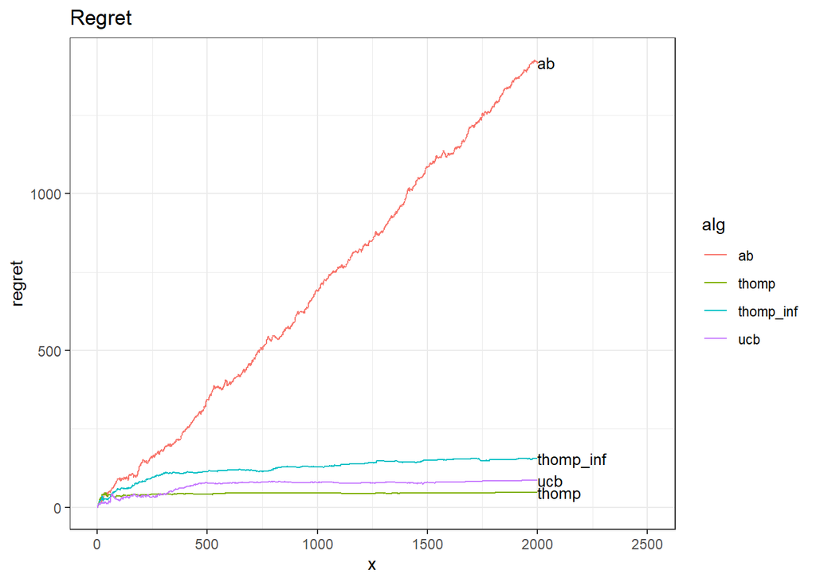

## Regret over multiple iterations with 95% confidence interval

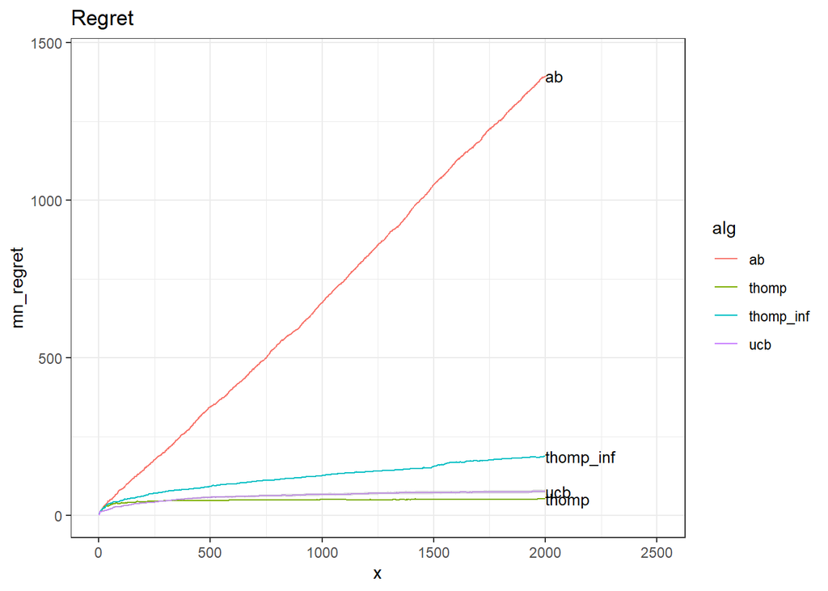

Regret seems to be consistent across multiple iterations for all algorithms